# Optimal Treatment Analysis

## Outcome Variable

**Outcome Variable:** haz

## Predictor Variables

**Intervention Variable:** nrooms

**Adjustment Set:**

- arm
- sex
- W_mage
- meducyrs
- feducyrs
- hhwealth_quart
- hfoodsec
- W_mhtcm
- W_mwtkg
- W_mbmi
- W_nchldlt5
- W_parity
- impfloor
- impsan
- safeh20
- delta_W_mage
- delta_meducyrs
- delta_feducyrs
- delta_hhwealth_quart
- delta_hfoodsec
- delta_W_mhtcm
- delta_W_mwtkg
- delta_W_mbmi
- delta_W_nchldlt5
- delta_W_parity
- delta_impfloor
- delta_impsan
- delta_safeh20

## Stratifying Variables

The analysis was stratified on these variable(s):

- agecat
- studyid
- country

## Data Summary

| agecat | studyid | country | nrooms | n_cell | n |
| --- | --- | --- | --- | --- | --- |
| Birth | ki0047075b-MAL-ED | BANGLADESH | 4+ | 12 | 213 |
| Birth | ki0047075b-MAL-ED | BANGLADESH | 1 | 130 | 213 |
| Birth | ki0047075b-MAL-ED | BANGLADESH | 2 | 46 | 213 |
| Birth | ki0047075b-MAL-ED | BANGLADESH | 3 | 25 | 213 |
| Birth | ki0047075b-MAL-ED | BRAZIL | 4+ | 30 | 60 |
| Birth | ki0047075b-MAL-ED | BRAZIL | 1 | 0 | 60 |
| Birth | ki0047075b-MAL-ED | BRAZIL | 2 | 10 | 60 |
| Birth | ki0047075b-MAL-ED | BRAZIL | 3 | 20 | 60 |
| Birth | ki0047075b-MAL-ED | INDIA | 4+ | 2 | 41 |
| Birth | ki0047075b-MAL-ED | INDIA | 1 | 18 | 41 |
| Birth | ki0047075b-MAL-ED | INDIA | 2 | 17 | 41 |
| Birth | ki0047075b-MAL-ED | INDIA | 3 | 4 | 41 |
| Birth | ki0047075b-MAL-ED | NEPAL | 4+ | 15 | 26 |
| Birth | ki0047075b-MAL-ED | NEPAL | 1 | 7 | 26 |
| Birth | ki0047075b-MAL-ED | NEPAL | 2 | 2 | 26 |
| Birth | ki0047075b-MAL-ED | NEPAL | 3 | 2 | 26 |
| Birth | ki0047075b-MAL-ED | PERU | 4+ | 107 | 215 |
| Birth | ki0047075b-MAL-ED | PERU | 1 | 13 | 215 |
| Birth | ki0047075b-MAL-ED | PERU | 2 | 45 | 215 |
| Birth | ki0047075b-MAL-ED | PERU | 3 | 50 | 215 |
| Birth | ki0047075b-MAL-ED | SOUTH AFRICA | 4+ | 67 | 96 |
| Birth | ki0047075b-MAL-ED | SOUTH AFRICA | 1 | 5 | 96 |
| Birth | ki0047075b-MAL-ED | SOUTH AFRICA | 2 | 12 | 96 |
| Birth | ki0047075b-MAL-ED | SOUTH AFRICA | 3 | 12 | 96 |
| Birth | ki0047075b-MAL-ED | TANZANIA, UNITED REPUBLIC OF | 4+ | 49 | 120 |
| Birth | ki0047075b-MAL-ED | TANZANIA, UNITED REPUBLIC OF | 1 | 9 | 120 |
| Birth | ki0047075b-MAL-ED | TANZANIA, UNITED REPUBLIC OF | 2 | 31 | 120 |
| Birth | ki0047075b-MAL-ED | TANZANIA, UNITED REPUBLIC OF | 3 | 31 | 120 |
| Birth | ki1000108-CMC-V-BCS-2002 | INDIA | 4+ | 5 | 92 |
| Birth | ki1000108-CMC-V-BCS-2002 | INDIA | 1 | 38 | 92 |

[output cut: 162 more lines]

The following strata were considered:

- agecat: 24 months, studyid: ki0047075b-MAL-ED, country: BANGLADESH
- agecat: 24 months, studyid: ki0047075b-MAL-ED, country: BRAZIL
- agecat: 24 months, studyid: ki0047075b-MAL-ED, country: INDIA
- agecat: 24 months, studyid: ki0047075b-MAL-ED, country: NEPAL
- agecat: 24 months, studyid: ki0047075b-MAL-ED, country: PERU
- agecat: 24 months, studyid: ki0047075b-MAL-ED, country: SOUTH AFRICA
- agecat: 24 months, studyid: ki0047075b-MAL-ED, country: TANZANIA, UNITED REPUBLIC OF
- agecat: 24 months, studyid: ki1000108-CMC-V-BCS-2002, country: INDIA
- agecat: 24 months, studyid: ki1000108-IRC, country: INDIA
- agecat: 24 months, studyid: ki1017093b-PROVIDE, country: BANGLADESH
- agecat: 24 months, studyid: ki1017093c-NIH-Crypto, country: BANGLADESH
- agecat: 24 months, studyid: ki1113344-GMS-Nepal, country: NEPAL
- agecat: 24 months, studyid: ki1114097-CONTENT, country: PERU
- agecat: 24 months, studyid: ki1135781-COHORTS, country: INDIA
- agecat: 24 months, studyid: kiGH5241-JiVitA-3, country: BANGLADESH
- agecat: 24 months, studyid: kiGH5241-JiVitA-4, country: BANGLADESH
- agecat: 6 months, studyid: ki0047075b-MAL-ED, country: BANGLADESH
- agecat: 6 months, studyid: ki0047075b-MAL-ED, country: BRAZIL
- agecat: 6 months, studyid: ki0047075b-MAL-ED, country: INDIA
- agecat: 6 months, studyid: ki0047075b-MAL-ED, country: NEPAL
- agecat: 6 months, studyid: ki0047075b-MAL-ED, country: PERU
- agecat: 6 months, studyid: ki0047075b-MAL-ED, country: SOUTH AFRICA
- agecat: 6 months, studyid: ki0047075b-MAL-ED, country: TANZANIA, UNITED REPUBLIC OF
- agecat: 6 months, studyid: ki1000108-CMC-V-BCS-2002, country: INDIA
- agecat: 6 months, studyid: ki1000108-IRC, country: INDIA
- agecat: 6 months, studyid: ki1017093b-PROVIDE, country: BANGLADESH
- agecat: 6 months, studyid: ki1017093c-NIH-Crypto, country: BANGLADESH
- agecat: 6 months, studyid: ki1113344-GMS-Nepal, country: NEPAL
- agecat: 6 months, studyid: ki1114097-CONTENT, country: PERU
- agecat: 6 months, studyid: ki1135781-COHORTS, country: INDIA
- agecat: 6 months, studyid: kiGH5241-JiVitA-3, country: BANGLADESH
- agecat: 6 months, studyid: kiGH5241-JiVitA-4, country: BANGLADESH
- agecat: Birth, studyid: ki0047075b-MAL-ED, country: BANGLADESH
- agecat: Birth, studyid: ki0047075b-MAL-ED, country: BRAZIL
- agecat: Birth, studyid: ki0047075b-MAL-ED, country: INDIA
- agecat: Birth, studyid: ki0047075b-MAL-ED, country: NEPAL
- agecat: Birth, studyid: ki0047075b-MAL-ED, country: PERU
- agecat: Birth, studyid: ki0047075b-MAL-ED, country: SOUTH AFRICA
- agecat: Birth, studyid: ki0047075b-MAL-ED, country: TANZANIA, UNITED REPUBLIC OF
- agecat: Birth, studyid: ki1000108-CMC-V-BCS-2002, country: INDIA
- agecat: Birth, studyid: ki1000108-IRC, country: INDIA
- agecat: Birth, studyid: ki1017093b-PROVIDE, country: BANGLADESH
- agecat: Birth, studyid: ki1017093c-NIH-Crypto, country: BANGLADESH
- agecat: Birth, studyid: ki1113344-GMS-Nepal, country: NEPAL
- agecat: Birth, studyid: ki1114097-CONTENT, country: PERU
- agecat: Birth, studyid: ki1135781-COHORTS, country: INDIA
- agecat: Birth, studyid: kiGH5241-JiVitA-3, country: BANGLADESH
- agecat: Birth, studyid: kiGH5241-JiVitA-4, country: BANGLADESH

### Dropped Strata

Some strata were dropped due to rare outcomes:

- agecat: Birth, studyid: ki0047075b-MAL-ED, country: BRAZIL
- agecat: Birth, studyid: ki0047075b-MAL-ED, country: INDIA
- agecat: Birth, studyid: ki0047075b-MAL-ED, country: NEPAL
- agecat: Birth, studyid: ki1114097-CONTENT, country: PERU
- agecat: 6 months, studyid: ki0047075b-MAL-ED, country: BRAZIL
- agecat: 24 months, studyid: ki0047075b-MAL-ED, country: BRAZIL

## Methods Detail

We’re interested in the causal parameters $E[Y_a]$ for all values of $a \in \mathcal{A}$. These parameters represent the mean outcome if, possibly contrary to fact, we intervened to set all units to have $A=a$. Under the randomization and positivity assumptions, these are identified by the statistical parameters $\psi_a=E_W[E_{Y|A,W}(Y|A=a,W)]$. In addition, we’re interested in the mean of $Y$, $E[Y]$ under no intervention (the observed mean). We will estimate these parameters by using SuperLearner to fit the relevant likelihood factors – $E_{Y|A,W}(Y|A=a,W)$ and $p(A=a|W)$, and then updating our likelihood fit using a joint TMLE.

For unadjusted analyses ($W=\{\}$), initial likelihoods were estimated using Lrnr_glm to estimate the simple $E(Y|A)$ and Lrnr_mean to estimate $p(A)$. For adjusted analyses, a small library containing Lrnr_glmnet, Lrnr_xgboost, and Lrnr_mean was used.

Having estimated these parameters, we will then use the delta method to estimate relative risks and attributable risks relative to a prespecified baseline level of $A$.

# Results Detail

## Results Plots

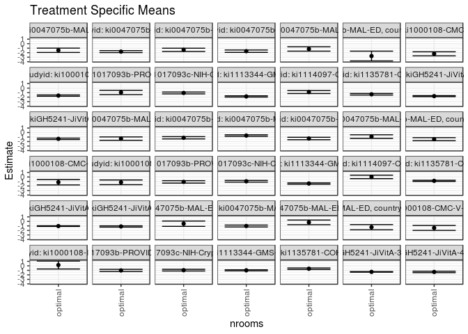

## Results Table

### Parameter: TSM

| agecat | studyid | country | intervention_level | baseline_level | estimate | ci_lower | ci_upper |
| --- | --- | --- | --- | --- | --- | --- | --- |
| Birth | ki0047075b-MAL-ED | BANGLADESH | optimal | observed | -0.5073425 | -1.0976627 | 0.0829777 |
| Birth | ki0047075b-MAL-ED | PERU | optimal | observed | -1.0214351 | -1.2323052 | -0.8105650 |
| Birth | ki0047075b-MAL-ED | SOUTH AFRICA | optimal | observed | -0.2135351 | -0.7291226 | 0.3020524 |
| Birth | ki0047075b-MAL-ED | TANZANIA, UNITED REPUBLIC OF | optimal | observed | -1.2823119 | -1.8559204 | -0.7087034 |
| Birth | ki1000108-CMC-V-BCS-2002 | INDIA | optimal | observed | -1.4422996 | -1.9932363 | -0.8913630 |
| Birth | ki1000108-IRC | INDIA | optimal | observed | 0.1794528 | -0.7008873 | 1.0597928 |
| Birth | ki1017093b-PROVIDE | BANGLADESH | optimal | observed | -1.0207861 | -1.2591326 | -0.7824396 |
| Birth | ki1017093c-NIH-Crypto | BANGLADESH | optimal | observed | -0.9632318 | -1.1516652 | -0.7747985 |
| Birth | ki1113344-GMS-Nepal | NEPAL | optimal | observed | -0.9944128 | -1.1196044 | -0.8692211 |
| Birth | ki1135781-COHORTS | INDIA | optimal | observed | -0.6382579 | -0.8070130 | -0.4695028 |
| Birth | kiGH5241-JiVitA-3 | BANGLADESH | optimal | observed | -1.3390713 | -1.4021610 | -1.2759815 |
| Birth | kiGH5241-JiVitA-4 | BANGLADESH | optimal | observed | -1.3520334 | -1.5064715 | -1.1975952 |
| 6 months | ki0047075b-MAL-ED | BANGLADESH | optimal | observed | -1.3469999 | -1.7222542 | -0.9717455 |
| 6 months | ki0047075b-MAL-ED | INDIA | optimal | observed | -1.1602017 | -1.4132476 | -0.9071559 |
| 6 months | ki0047075b-MAL-ED | NEPAL | optimal | observed | -0.6756629 | -0.8488905 | -0.5024352 |
| 6 months | ki0047075b-MAL-ED | PERU | optimal | observed | -1.3265161 | -1.5941047 | -1.0589275 |
| 6 months | ki0047075b-MAL-ED | SOUTH AFRICA | optimal | observed | -0.8933302 | -1.2866561 | -0.5000042 |
| 6 months | ki0047075b-MAL-ED | TANZANIA, UNITED REPUBLIC OF | optimal | observed | -1.4723995 | -1.8053406 | -1.1394584 |
| 6 months | ki1000108-CMC-V-BCS-2002 | INDIA | optimal | observed | -1.1691009 | -1.7631308 | -0.5750709 |
| 6 months | ki1000108-IRC | INDIA | optimal | observed | -1.1916468 | -1.7128935 | -0.6704000 |
| 6 months | ki1017093b-PROVIDE | BANGLADESH | optimal | observed | -1.0876042 | -1.3591801 | -0.8160283 |
| 6 months | ki1017093c-NIH-Crypto | BANGLADESH | optimal | observed | -0.9587223 | -1.1507158 | -0.7667288 |
| 6 months | ki1113344-GMS-Nepal | NEPAL | optimal | observed | -1.4541516 | -1.5943111 | -1.3139920 |
| 6 months | ki1114097-CONTENT | PERU | optimal | observed | 0.0157444 | -0.3692169 | 0.4007057 |
| 6 months | ki1135781-COHORTS | INDIA | optimal | observed | -0.8577604 | -0.9798239 | -0.7356970 |
| 6 months | kiGH5241-JiVitA-3 | BANGLADESH | optimal | observed | -1.0361547 | -1.1121482 | -0.9601612 |
| 6 months | kiGH5241-JiVitA-4 | BANGLADESH | optimal | observed | -1.1199745 | -1.2585485 | -0.9814006 |
| 24 months | ki0047075b-MAL-ED | BANGLADESH | optimal | observed | -1.4682774 | -1.9457812 | -0.9907736 |
| 24 months | ki0047075b-MAL-ED | INDIA | optimal | observed | -1.7635223 | -1.9787715 | -1.5482731 |
| 24 months | ki0047075b-MAL-ED | NEPAL | optimal | observed | -1.3705513 | -1.7299537 | -1.0111489 |
| 24 months | ki0047075b-MAL-ED | PERU | optimal | observed | -1.6658397 | -1.9333197 | -1.3983597 |
| 24 months | ki0047075b-MAL-ED | SOUTH AFRICA | optimal | observed | -1.1750630 | -1.6589599 | -0.6911661 |
| 24 months | ki0047075b-MAL-ED | TANZANIA, UNITED REPUBLIC OF | optimal | observed | -2.7467691 | -3.8324952 | -1.6610430 |
| 24 months | ki1000108-CMC-V-BCS-2002 | INDIA | optimal | observed | -2.2483220 | -2.6965910 | -1.8000531 |
| 24 months | ki1000108-IRC | INDIA | optimal | observed | -1.6613701 | -1.8047626 | -1.5179775 |
| 24 months | ki1017093b-PROVIDE | BANGLADESH | optimal | observed | -0.9573759 | -1.4405554 | -0.4741963 |
| 24 months | ki1017093c-NIH-Crypto | BANGLADESH | optimal | observed | -1.0736828 | -1.2776911 | -0.8696744 |
| 24 months | ki1113344-GMS-Nepal | NEPAL | optimal | observed | -1.8503368 | -1.9831844 | -1.7174892 |
| 24 months | ki1114097-CONTENT | PERU | optimal | observed | -0.8728894 | -1.2043159 | -0.5414628 |
| 24 months | ki1135781-COHORTS | INDIA | optimal | observed | -1.3754624 | -1.5486374 | -1.2022874 |
| 24 months | kiGH5241-JiVitA-3 | BANGLADESH | optimal | observed | -1.7792527 | -1.8904156 | -1.6680897 |
| 24 months | kiGH5241-JiVitA-4 | BANGLADESH | optimal | observed | -1.3992755 | -1.5585722 | -1.2399787 |

### Parameter: E(Y)

| agecat | studyid | country | intervention_level | baseline_level | estimate | ci_lower | ci_upper |
| --- | --- | --- | --- | --- | --- | --- | --- |
| Birth | ki0047075b-MAL-ED | BANGLADESH | observed | observed | -1.0530516 | -1.1896058 | -0.9164975 |
| Birth | ki0047075b-MAL-ED | PERU | observed | observed | -0.9141395 | -1.0364098 | -0.7918693 |
| Birth | ki0047075b-MAL-ED | SOUTH AFRICA | observed | observed | -0.5523958 | -0.7550074 | -0.3497843 |
| Birth | ki0047075b-MAL-ED | TANZANIA, UNITED REPUBLIC OF | observed | observed | -1.1225000 | -1.3335666 | -0.9114334 |
| Birth | ki1000108-CMC-V-BCS-2002 | INDIA | observed | observed | -0.9611957 | -1.1776967 | -0.7446946 |
| Birth | ki1000108-IRC | INDIA | observed | observed | -0.3079016 | -0.4694769 | -0.1463262 |
| Birth | ki1017093b-PROVIDE | BANGLADESH | observed | observed | -0.8851020 | -0.9601332 | -0.8100709 |
| Birth | ki1017093c-NIH-Crypto | BANGLADESH | observed | observed | -0.9094945 | -0.9809370 | -0.8380521 |
| Birth | ki1113344-GMS-Nepal | NEPAL | observed | observed | -1.0851580 | -1.1651811 | -1.0051350 |
| Birth | ki1135781-COHORTS | INDIA | observed | observed | -0.6777626 | -0.7107167 | -0.6448086 |
| Birth | kiGH5241-JiVitA-3 | BANGLADESH | observed | observed | -1.5898426 | -1.6091216 | -1.5705636 |
| Birth | kiGH5241-JiVitA-4 | BANGLADESH | observed | observed | -1.5236135 | -1.5727559 | -1.4744711 |
| 6 months | ki0047075b-MAL-ED | BANGLADESH | observed | observed | -1.2026806 | -1.3203025 | -1.0850586 |
| 6 months | ki0047075b-MAL-ED | INDIA | observed | observed | -1.2070638 | -1.3255909 | -1.0885368 |
| 6 months | ki0047075b-MAL-ED | NEPAL | observed | observed | -0.5615819 | -0.6741832 | -0.4489807 |
| 6 months | ki0047075b-MAL-ED | PERU | observed | observed | -1.3248549 | -1.4336721 | -1.2160378 |
| 6 months | ki0047075b-MAL-ED | SOUTH AFRICA | observed | observed | -1.0547925 | -1.1843544 | -0.9252306 |
| 6 months | ki0047075b-MAL-ED | TANZANIA, UNITED REPUBLIC OF | observed | observed | -1.3687449 | -1.4907629 | -1.2467270 |
| 6 months | ki1000108-CMC-V-BCS-2002 | INDIA | observed | observed | -1.4234508 | -1.5645974 | -1.2823042 |
| 6 months | ki1000108-IRC | INDIA | observed | observed | -1.2470123 | -1.3779341 | -1.1160906 |
| 6 months | ki1017093b-PROVIDE | BANGLADESH | observed | observed | -1.0916915 | -1.1661176 | -1.0172654 |
| 6 months | ki1017093c-NIH-Crypto | BANGLADESH | observed | observed | -1.1986783 | -1.2700937 | -1.1272630 |
| 6 months | ki1113344-GMS-Nepal | NEPAL | observed | observed | -1.3508392 | -1.4290633 | -1.2726152 |
| 6 months | ki1114097-CONTENT | PERU | observed | observed | -0.3139217 | -0.4868486 | -0.1409948 |
| 6 months | ki1135781-COHORTS | INDIA | observed | observed | -1.0413281 | -1.0740395 | -1.0086167 |
| 6 months | kiGH5241-JiVitA-3 | BANGLADESH | observed | observed | -1.3132988 | -1.3364412 | -1.2901565 |
| 6 months | kiGH5241-JiVitA-4 | BANGLADESH | observed | observed | -1.3440477 | -1.3813060 | -1.3067894 |
| 24 months | ki0047075b-MAL-ED | BANGLADESH | observed | observed | -1.9783962 | -2.1050210 | -1.8517715 |
| 24 months | ki0047075b-MAL-ED | INDIA | observed | observed | -1.8861894 | -2.0110006 | -1.7613783 |
| 24 months | ki0047075b-MAL-ED | NEPAL | observed | observed | -1.3075877 | -1.4270718 | -1.1881037 |
| 24 months | ki0047075b-MAL-ED | PERU | observed | observed | -1.7524710 | -1.8736426 | -1.6312994 |
| 24 months | ki0047075b-MAL-ED | SOUTH AFRICA | observed | observed | -1.6450595 | -1.7797240 | -1.5103950 |
| 24 months | ki0047075b-MAL-ED | TANZANIA, UNITED REPUBLIC OF | observed | observed | -2.6455607 | -2.7807256 | -2.5103959 |
| 24 months | ki1000108-CMC-V-BCS-2002 | INDIA | observed | observed | -2.5588679 | -2.6583730 | -2.4593629 |
| 24 months | ki1000108-IRC | INDIA | observed | observed | -1.8014906 | -1.8952579 | -1.7077232 |
| 24 months | ki1017093b-PROVIDE | BANGLADESH | observed | observed | -1.6024221 | -1.6857420 | -1.5191023 |
| 24 months | ki1017093c-NIH-Crypto | BANGLADESH | observed | observed | -1.4412646 | -1.5249156 | -1.3576135 |
| 24 months | ki1113344-GMS-Nepal | NEPAL | observed | observed | -1.8874180 | -1.9728588 | -1.8019773 |
| 24 months | ki1114097-CONTENT | PERU | observed | observed | -0.6962195 | -0.8674103 | -0.5250287 |
| 24 months | ki1135781-COHORTS | INDIA | observed | observed | -2.2131714 | -2.2523749 | -2.1739679 |
| 24 months | kiGH5241-JiVitA-3 | BANGLADESH | observed | observed | -2.0137471 | -2.0414306 | -1.9860636 |
| 24 months | kiGH5241-JiVitA-4 | BANGLADESH | observed | observed | -1.7803708 | -1.8158650 | -1.7448765 |

### Parameter: PAR

| agecat | studyid | country | intervention_level | baseline_level | estimate | ci_lower | ci_upper |
| --- | --- | --- | --- | --- | --- | --- | --- |
| Birth | ki0047075b-MAL-ED | BANGLADESH | optimal | observed | -0.5457091 | -1.1163233 | 0.0249051 |
| Birth | ki0047075b-MAL-ED | PERU | optimal | observed | 0.1072955 | -0.0674912 | 0.2820822 |
| Birth | ki0047075b-MAL-ED | SOUTH AFRICA | optimal | observed | -0.3388607 | -0.8807366 | 0.2030151 |
| Birth | ki0047075b-MAL-ED | TANZANIA, UNITED REPUBLIC OF | optimal | observed | 0.1598119 | -0.3890385 | 0.7086623 |
| Birth | ki1000108-CMC-V-BCS-2002 | INDIA | optimal | observed | 0.4811040 | -0.0421862 | 1.0043941 |
| Birth | ki1000108-IRC | INDIA | optimal | observed | -0.4873543 | -1.3382113 | 0.3635027 |
| Birth | ki1017093b-PROVIDE | BANGLADESH | optimal | observed | 0.1356841 | -0.0951156 | 0.3664837 |
| Birth | ki1017093c-NIH-Crypto | BANGLADESH | optimal | observed | 0.0537373 | -0.1228556 | 0.2303301 |
| Birth | ki1113344-GMS-Nepal | NEPAL | optimal | observed | -0.0907453 | -0.1840663 | 0.0025757 |
| Birth | ki1135781-COHORTS | INDIA | optimal | observed | -0.0395047 | -0.2057188 | 0.1267093 |
| Birth | kiGH5241-JiVitA-3 | BANGLADESH | optimal | observed | -0.2507713 | -0.3131236 | -0.1884190 |
| Birth | kiGH5241-JiVitA-4 | BANGLADESH | optimal | observed | -0.1715801 | -0.3200657 | -0.0230946 |
| 6 months | ki0047075b-MAL-ED | BANGLADESH | optimal | observed | 0.1443193 | -0.2280770 | 0.5167156 |
| 6 months | ki0047075b-MAL-ED | INDIA | optimal | observed | -0.0468621 | -0.2910389 | 0.1973147 |
| 6 months | ki0047075b-MAL-ED | NEPAL | optimal | observed | 0.1140810 | -0.0317920 | 0.2599539 |
| 6 months | ki0047075b-MAL-ED | PERU | optimal | observed | 0.0016612 | -0.2364634 | 0.2397858 |
| 6 months | ki0047075b-MAL-ED | SOUTH AFRICA | optimal | observed | -0.1614623 | -0.5398610 | 0.2169363 |
| 6 months | ki0047075b-MAL-ED | TANZANIA, UNITED REPUBLIC OF | optimal | observed | 0.1036545 | -0.2063949 | 0.4137040 |
| 6 months | ki1000108-CMC-V-BCS-2002 | INDIA | optimal | observed | -0.2543499 | -0.8346609 | 0.3259611 |
| 6 months | ki1000108-IRC | INDIA | optimal | observed | -0.0553656 | -0.5530708 | 0.4423397 |
| 6 months | ki1017093b-PROVIDE | BANGLADESH | optimal | observed | -0.0040873 | -0.2705322 | 0.2623576 |
| 6 months | ki1017093c-NIH-Crypto | BANGLADESH | optimal | observed | -0.2399560 | -0.4191412 | -0.0607707 |
| 6 months | ki1113344-GMS-Nepal | NEPAL | optimal | observed | 0.1033123 | -0.0155368 | 0.2221615 |
| 6 months | ki1114097-CONTENT | PERU | optimal | observed | -0.3296661 | -0.6703972 | 0.0110650 |
| 6 months | ki1135781-COHORTS | INDIA | optimal | observed | -0.1835676 | -0.3056195 | -0.0615158 |
| 6 months | kiGH5241-JiVitA-3 | BANGLADESH | optimal | observed | -0.2771441 | -0.3528265 | -0.2014616 |
| 6 months | kiGH5241-JiVitA-4 | BANGLADESH | optimal | observed | -0.2240731 | -0.3586180 | -0.0895282 |
| 24 months | ki0047075b-MAL-ED | BANGLADESH | optimal | observed | -0.5101188 | -0.9824210 | -0.0378166 |
| 24 months | ki0047075b-MAL-ED | INDIA | optimal | observed | -0.1226672 | -0.2911278 | 0.0457935 |
| 24 months | ki0047075b-MAL-ED | NEPAL | optimal | observed | 0.0629636 | -0.2690745 | 0.3950016 |
| 24 months | ki0047075b-MAL-ED | PERU | optimal | observed | -0.0866313 | -0.3327289 | 0.1594663 |
| 24 months | ki0047075b-MAL-ED | SOUTH AFRICA | optimal | observed | -0.4699965 | -0.9371937 | -0.0027994 |
| 24 months | ki0047075b-MAL-ED | TANZANIA, UNITED REPUBLIC OF | optimal | observed | 0.1012083 | -0.9468461 | 1.1492627 |
| 24 months | ki1000108-CMC-V-BCS-2002 | INDIA | optimal | observed | -0.3105459 | -0.7556657 | 0.1345740 |
| 24 months | ki1000108-IRC | INDIA | optimal | observed | -0.1401205 | -0.2510568 | -0.0291842 |
| 24 months | ki1017093b-PROVIDE | BANGLADESH | optimal | observed | -0.6450463 | -1.1174020 | -0.1726905 |
| 24 months | ki1017093c-NIH-Crypto | BANGLADESH | optimal | observed | -0.3675818 | -0.5603942 | -0.1747694 |
| 24 months | ki1113344-GMS-Nepal | NEPAL | optimal | observed | -0.0370812 | -0.1384700 | 0.0643075 |
| 24 months | ki1114097-CONTENT | PERU | optimal | observed | 0.1766698 | -0.1042980 | 0.4576377 |
| 24 months | ki1135781-COHORTS | INDIA | optimal | observed | -0.8377090 | -1.0102194 | -0.6651986 |
| 24 months | kiGH5241-JiVitA-3 | BANGLADESH | optimal | observed | -0.2344944 | -0.3396968 | -0.1292920 |
| 24 months | kiGH5241-JiVitA-4 | BANGLADESH | optimal | observed | -0.3810953 | -0.5340682 | -0.2281223 |